# 3-ый этап индивидуального проекта

Основы информационной безопасности

Верниковская Е. А., НПИбд-01-23

Российский университет дружбы народов, Москва, Россия

10 апреля 2025

# Вводная часть

## Цель работы

Приобретение практических навыков по использованию инструмента Hydra для бутфорса паролей

## Задание

1. Реалзовать эксплуатацию уязвимости с помощью бутфорса паролей

# Выполнение 3-ого этапа индивидуального проекта

## Распаковка архива с паролями

Чтобы пробутфорсить пароль, нужно для начала найти большой список часто используемых паролей. Возьмём стандартный список паролей rockyou.txt для kali linux(рис. 1)

[figure not shown]

Загрузка архива со списком паролей

## Распаковка архива с паролями

Далее распакуем архив командой *sudo gzip -d*. Нужно сделать так, чтобы файл rockyou.txt находился в домашней директории (рис. 2), (рис. 3)

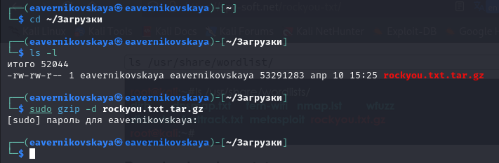

Распаковка архива со списком паролей

## Распаковка архива с паролями

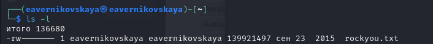

Файл со списком паролей в домашней директори

## Настройка cookie

Далее зайдём на сайт DVWA, который был получен в ходе предыдущего этапа индивидуального проекта. Для запроса hydra, который мы будем исползовать позже, нам понадобятся параметры cookie с этого сайта. Для того чтобы получить информацию о параметрах cookie надо установить расширение для браузера (рис. 4)

[figure not shown]

Установка расширения

## Настройка cookie

Теперь мы можем увидеть параметры cookie, а также можем их скопировать (рис. 5)

[figure not shown]

Параметры cookie

## Запрос к hydra

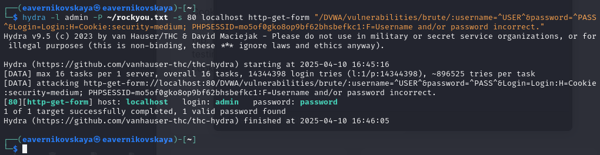

Запрос к hydra

## Запрос к hydra

Спустя время появится результат с подходящим паролем. Введём полученные данные на сайт для проверки. После мы получим положительный результат проверки пароля. Всё правильно и всё хорошо!!! (рис. 7), (рис. 8)

[figure not shown]

Ввод полученного результата в уязвимую форму

## Запрос к hydra

[figure not shown]

Результат

# Подведение итогов

## Выводы

В ходе выполнения 3-ого этапа индивидуального проекта мы приобрели практические навыки работы по использованию инструмента hydra для бутфорса паролей.

## Список литературы

1. Этапы реализации проекта [Электронный ресурс] URL: https://esystem.rudn.ru/mod/page/view.php?id=1220336
2. Словарь Rockyou.txt где находится в Kali Linux и как скачать [Электронный ресурс] URL: https://spy-soft.net/rockyou-txt/
3. How to Brute Force Attack on Web Forms? [Step-by-Step] [Электронный ресурс] URL: https://www.golinuxcloud.com/brute-force-attack-web-forms/
4. Расширение Cookie-Editor [Электронный ресурс] URL: https://addons.mozilla.org/en-US/firefox/addon/cookie-editor/?utm_campaign=external-cookie-editor.com